# U-Haul Data

Alexander Cardazzi

January 23, 2021

# U-Haul Data

### Picture of Trucks

**10' Truck: Studio to 1 Bedroom Apt.**

[figure not shown]

**15' Truck: 1 Bedroom Home to 2 Bedroom Apt.**

[figure not shown]

**20' Truck: 2 Bedroom Home to 3 Bedroom Apt.**

[figure not shown]

**26' Truck: 3 Bedroom Home to 4 Bedroom Home**

[figure not shown]

### 10' Truck

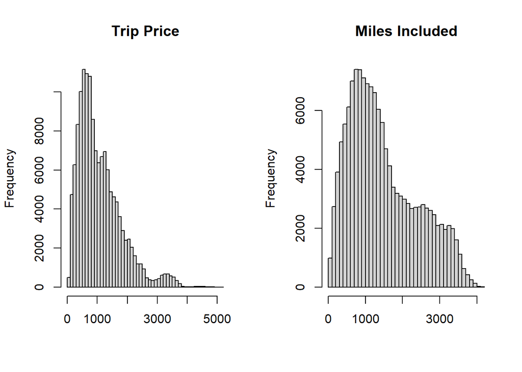

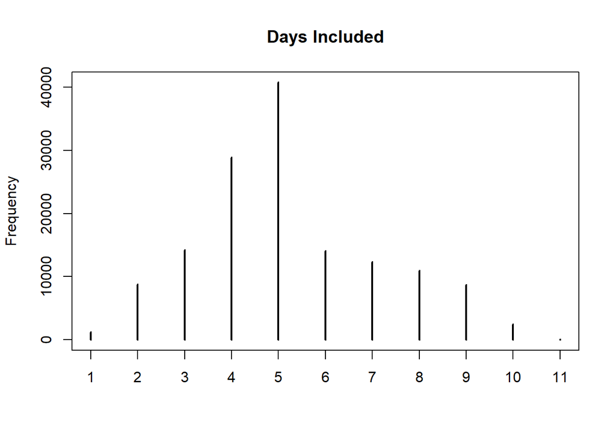

```r
uhaul <- all1[all1$truck_type == "10' Truck" & all1$to != all1$from,]

par(mfrow = c(1, 2))
hist(uhaul$trip_price_1, breaks = 50, main = "Trip Price", ylab = "Frequency", xlab = "")
hist(uhaul$miles_included, breaks = 50, main = "Miles Included", ylab = "Frequency", xlab = "")
par(mfrow = c(1, 1))
plot(table(uhaul$days_included), main = "Days Included", ylab = "Frequency")
```

Next, I plotted trip mileage vs trip price. I color coded trips that take an odd (even) number of days red (blue). There is substantial variation in price over different levels of mileage, but there are clear "streaks" or pattern that emerge. I select the trips that are expected to take 7 days to take a closer look.

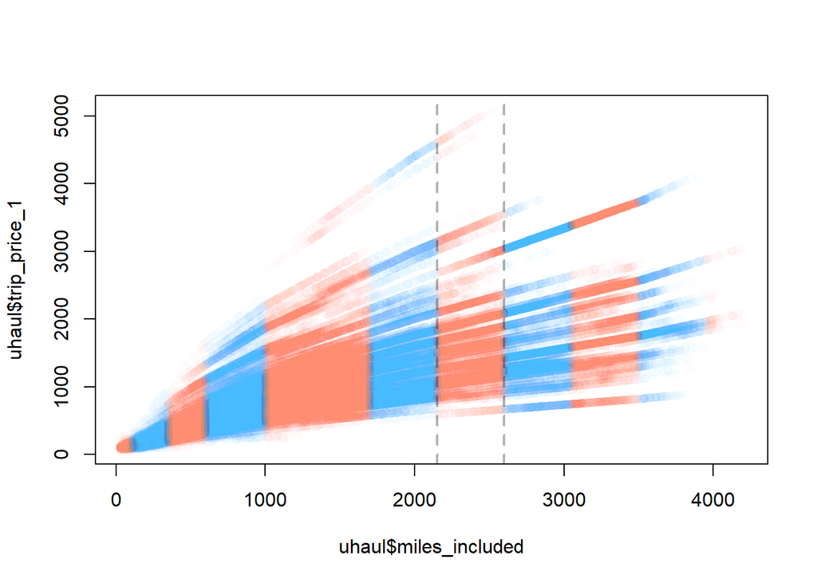

```r
plot(uhaul$miles_included, uhaul$trip_price_1,
     col = alpha(ifelse(uhaul$days_included %% 2 == 0, "DodgerBlue", "tomato"), .01), pch = 19)
abline(v = c(min(uhaul$miles_included[uhaul$days_included == 7]),
             max(uhaul$miles_included[uhaul$days_included == 7])),
       col = alpha("black", .3),lty = 2, lwd = 2)
```

The six most expensive trips (of 7 days) are as follows:

```r
lim <- uhaul$days_included == 7
head(uhaul[lim,][order(-uhaul$trip_price_1[lim]),c("from", "to", "miles_included")])
```

```
##                      from                to miles_included
## 699082     Santa Maria-CA Cape Girardeau-MO           2524
## 806183         Visalia-CA    Grand Forks-ND           2491
## 692743 San Luis Obispo-CA    Grand Forks-ND           2452
## 692275 San Luis Obispo-CA Cape Girardeau-MO           2444
## 699436     Santa Maria-CA          Fargo-ND           2441
## 284374          Fresno-CA    Grand Forks-ND           2428
```

The six least expensive trips are as follows:

```r
lim <- uhaul$days_included == 7
head(uhaul[lim,][order(uhaul$trip_price_1[lim]),c("from", "to", "miles_included")])
```

```
##                  from           to miles_included
## 270593    Florence-AL El Centro-CA           2152
## 596002 Panama City-FL   Phoenix-AZ           2158
## 520155      Mobile-AL El Centro-CA           2163
## 601200   Pensacola-FL      Yuma-AZ           2161
## 200265      Daphne-AL El Centro-CA           2168
## 787863  Tuscaloosa-AL El Centro-CA           2168
```

Something interesting about these top six trips is that these are the most expensive trips in the entire dataset - even moreso than trips almost two times as long. Further, there exist trips of two days that are more expensive than these bottom six trips. It does not appear that mileage is the most important factor to U-Haul.

An interesting feature of the data is the lack of symmetry in trip pricing. Like the example you used in your email, the price to go from LA to Dallas is different than the price from Dallas to LA. I investigate this by finding the difference in price between every symmetric trip.

```r
diff <- uhaul$trip_price_1 - uhaul$trip_price_1[match(paste0(uhaul$from, "_", uhaul$to), paste0(uhaul$to, "_", uhaul$from))]
p1 <- uhaul$trip_price_1
d1 <- uhaul$miles_included
t1 <- paste0(uhaul$from, " to ", uhaul$to)

p1 <- p1[diff >= 0]
d1 <- d1[diff >= 0]
t1 <- t1[diff >= 0]
diff <- diff[diff >= 0]

p1 <- p1[order(-diff)]
d1 <- d1[order(-diff)]
t1 <- t1[order(-diff)]
diff <- diff[order(-diff)]

p1 <- p1[1:(length(diff) - (sum(diff == 0)/2))]
d1 <- d1[1:(length(diff) - (sum(diff == 0)/2))]
t1 <- t1[1:(length(diff) - (sum(diff == 0)/2))]
diff <- diff[1:(length(diff) - (sum(diff == 0)/2))]
```

In the data, only 2.61% of routes have symmetric prices. Below I plot the distribution of the price differences with and without these 2.61%. Next, I plot the more expensive trip on the x-axis and the cheaper on the y. I then plot the the more expensive trip vs the difference. Finally, I print the distance vs the price difference.

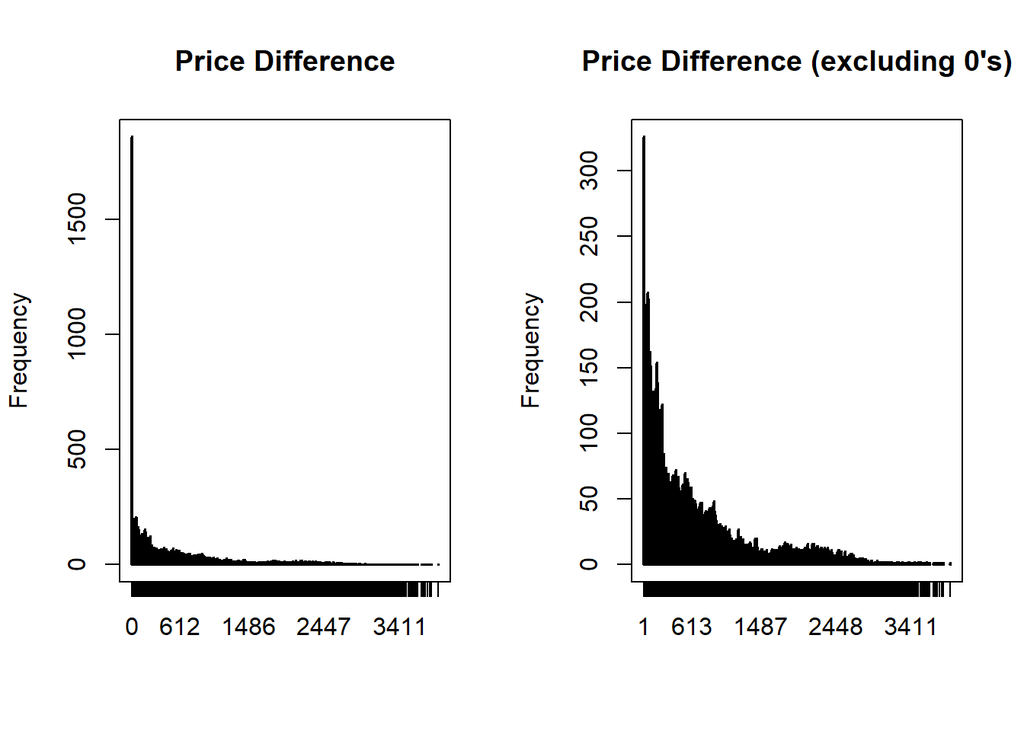

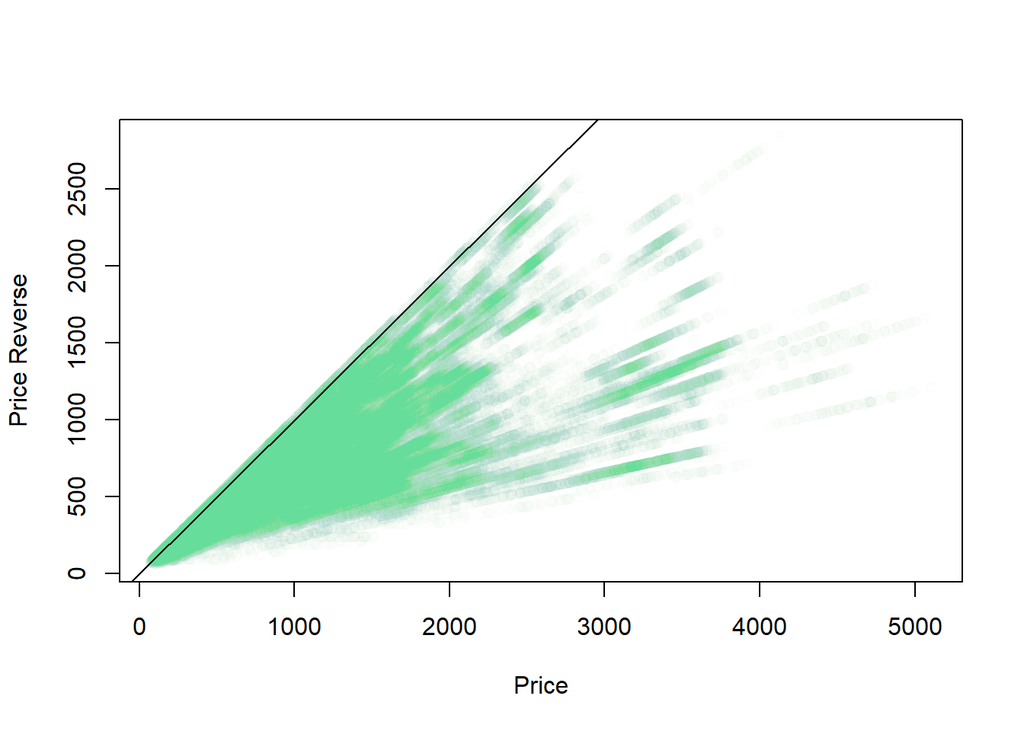

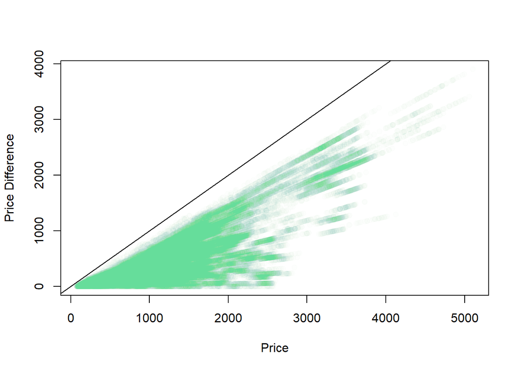

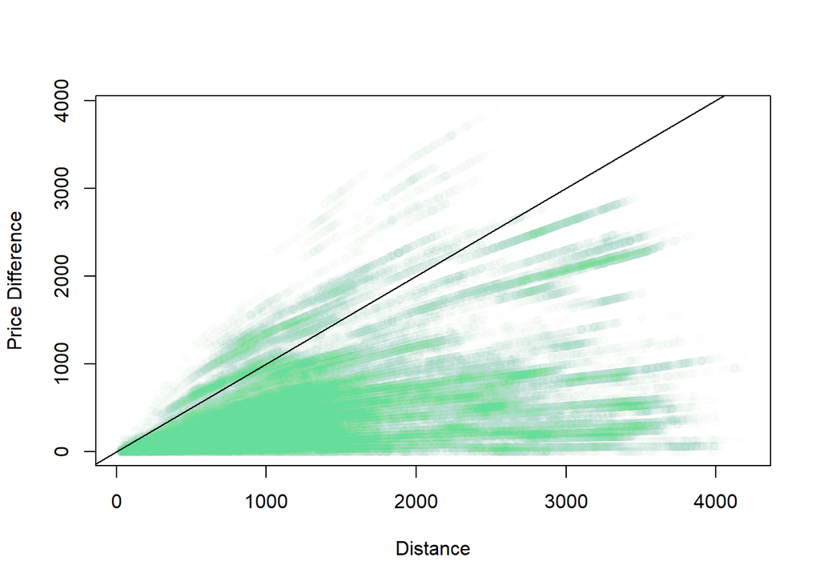

```r
par(mfrow = c(1,2))
plot(table(diff), main = "Price Difference", xlab = "", ylab = "Frequency")
plot(table(diff[diff>0]), main = "Price Difference (excluding 0's)", ylab = "Frequency", xlab = "")
par(mfrow = c(1,1))

plot(p1, p1 - diff, pch = 19, col = alpha("MediumSeaGreen", .01),
     main = "", xlab = "Price", ylab = "Price Reverse")
abline(0, 1)

plot(p1, diff, pch = 19, col = alpha("MediumSeaGreen", .01),
     main = "", xlab = "Price", ylab = "Price Difference")
abline(0, 1)

plot(d1, diff, pch = 19, col = alpha("MediumSeaGreen", .01),
     main = "", xlab = "Distance", ylab = "Price Difference")
abline(0, 1)
```

Below are the trips with the largest price differences in total. It seems that U-Haul wants to keep people out of Cape Girardeau at all costs, for whatever reason. Below is a Google Maps screenshot of where this city is located. It is hillariously at the centroid of Memphis, Nashville and St. Louis.

```r
data.frame(Route = t1[1:10],
           Miles = d1[1:10],
           Price = p1[1:10],
           `P Reverse` = p1[1:10]-diff[1:10],
           `P Difference` = diff[1:10]
           )
```

```
##                                      Route Miles Price P.Reverse P.Difference
## 1      Santa Maria-CA to Cape Girardeau-MO  2524  5105      1206         3899
## 2  San Luis Obispo-CA to Cape Girardeau-MO  2444  4995      1180         3815
## 3           Merced-CA to Cape Girardeau-MO  2427  4974      1177         3797
## 4           Madera-CA to Cape Girardeau-MO  2391  4927      1165         3762
## 5           Fresno-CA to Cape Girardeau-MO  2367  4896      1157         3739
## 6           Merced-CA to Jefferson City-MO  2343  4864      1149         3715
## 7          Hanford-CA to Cape Girardeau-MO  2338  4854      1148         3706
## 8           Oxnard-CA to Cape Girardeau-MO  2333  4849      1147         3702
## 9          Visalia-CA to Cape Girardeau-MO  2329  4844      1145         3699
## 10                Merced-CA to Columbia-MO  2318  4828      1141         3687
```

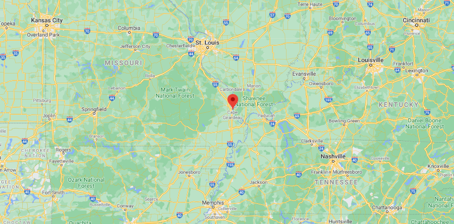

I ran some basic regressions to look at how miles influneces price, even though clearly there is more at work. Surprisingly, FE do not change the relationships all that much. Rather, I think it has to do with the relativity between the two cities. For example: going from city A to city B might only matter insofar that A is more (less) desireable than B. This model is assuming the overall, "global" desireability of A and B matter, and I am not convinced that this is the case.

```r
reg1 <- lfe::felm(trip_price_1 ~ miles_included, data = uhaul)
reg2 <- lfe::felm(trip_price_1 ~ miles_included + I(miles_included^2), data = uhaul)
reg3 <- lfe::felm(trip_price_1 ~ miles_included + I(miles_included^2) + I(miles_included^3), data = uhaul)
reg4 <- lfe::felm(trip_price_1 ~ miles_included + I(miles_included^2) + I(miles_included^3) | to + from, data = uhaul)

stargazer::stargazer(reg1, reg2, reg3, reg4,
                     type = "text",
                     add.lines = list(c("To / From FE", "No", "No", "No", "Yes")),
                     omit.stat = c("ser", "f"))
```

```
##
## ==============================================================
##                                Dependent variable:
##                    -------------------------------------------
##                                   trip_price_1
##                       (1)        (2)        (3)        (4)
## --------------------------------------------------------------
## miles_included      0.581***   0.916***   0.939***   1.146***
##                     (0.001)    (0.006)    (0.014)    (0.008)
##
## I(miles_included2)            -0.0001*** -0.0001*** -0.0002***
##                               (0.00000)  (0.00001)  (0.00000)
##
## I(miles_included3)                         0.000*   0.00000***
##                                           (0.000)    (0.000)
##
## Constant           226.911*** 17.105***    8.841
##                     (2.513)    (4.197)    (6.151)
##
## --------------------------------------------------------------
## To / From FE           No         No         No        Yes
## Observations        142,506    142,506    142,506    142,506
## R2                   0.531      0.544      0.544      0.878
## Adjusted R2          0.531      0.544      0.544      0.877
## ==============================================================
## Note:                              *p<0.1; **p<0.05; ***p<0.01
```

In the next two regressions, I try to explain the *price difference* between two routes rather than the price for a single route. I think is an interesting way to think about what we are trying to do. For example, I think this regression would benefit most from a variable that measures the difference in the economic freedom index (or whatever measurement) between the two cities.

```r
str <- unlist(strsplit(t1, " to "))
from1 <- str[c(T,F)]
to1 <- str[!c(T,F)]
reg5 <- lfe::felm(diff ~ d1 + p1)
reg6 <- lfe::felm(diff ~ d1 + p1 | from1 + to1)
stargazer::stargazer(reg5, reg6,
                     type = "text",
                     add.lines = list(c("To / From FE", "No", "Yes")),
                     omit.stat = c("ser", "f"))
```

```
##
## =========================================
##                  Dependent variable:
##              ----------------------------
##                          diff
##                    (1)           (2)
## -----------------------------------------
## d1              -0.413***     -0.434***
##                  (0.002)       (0.002)
##
## p1              0.962***       0.896***
##                  (0.002)       (0.002)
##
## Constant       -144.271***
##                  (1.741)
##
## -----------------------------------------
## To / From FE       No            Yes
## Observations     71,253         71,253
## R2                0.847         0.927
## Adjusted R2       0.847         0.926
## =========================================
## Note:         *p<0.1; **p<0.05; ***p<0.01
```